# QuantBio Coding test

Nusrat Epsi

## Results

Following packages need to be loaded:

require(ggplot2)

require(tidyverse)

require(formattable)

require(ggpubr)

require(scales)

Import TCGA mutation data and Clinical data:

```r
TCGA_mutation_data <- read.csv("~/R stuff/test coding/mc3.v0.2.8.PUBLIC.filtered_qual_SNP_1_22_21_COSMIC_census.maf")
clinical_data <- read.csv("~/R stuff/test coding/tcga_finalized_clinical_data.csv", row.names=1)
```

Merge TCGA mutation data and Clinical data based on Patient barcode:

```r
#Linking mutation data and clinical data
#trimming column names
TCGA_mutation_data$bcr_patient_barcode <- substring(TCGA_mutation_data$Tumor_Sample_Barcode, 1,12)

#Checking if we have the same Patient barcode in the both dataset
clinical_data <- subset(clinical_data, bcr_patient_barcode %in% unique(TCGA_mutation_data$bcr_patient_barcode))

#Merge both dataset based on patient barcode
TCGA_mutation_data <- merge( clinical_data[,c("bcr_patient_barcode", "type", "age_at_initial_pathologic_diagnosis")], TCGA_mutation_data,by = "bcr_patient_barcode", all = TRUE)
```

#1. a. Plot shows frequency of KRAS mutation by cancer type (sorted from most to least) in TCGA

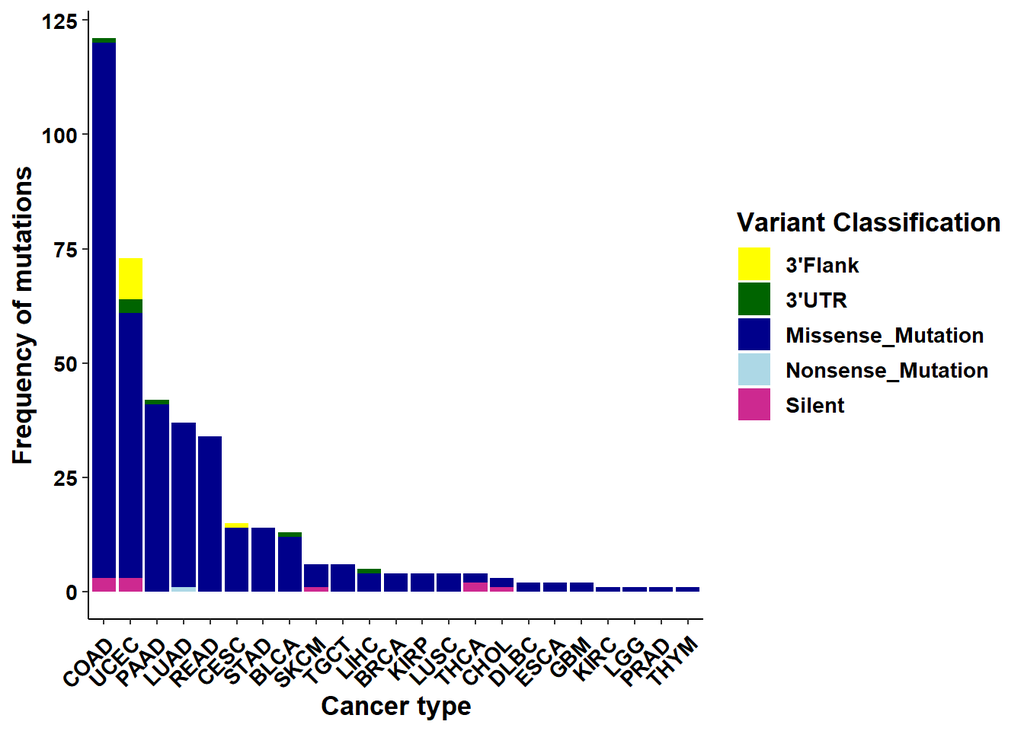

```r
data_KRAS <- subset(TCGA_mutation_data, Hugo_Symbol == "KRAS")

data_KRAS_plot <- as.data.frame(table(data_KRAS$type, data_KRAS$Variant_Classification))
ggplot(data=data_KRAS_plot, aes(x=reorder(Var1,-Freq), y=Freq, fill = Var2)) +
  geom_bar(stat="identity") + theme_classic() + labs(y = "Frequency of mutations", x = "Cancer type",fill = "Variant Classification") +
  theme(axis.text.x = element_text(angle = 45, vjust = 0.9, hjust=1),
        text = element_text(face = "bold", size = 13, color = "black"),
        axis.text = element_text(color = "black"))+
  scale_fill_manual(values = c("yellow", "darkgreen", "blue4", "lightblue", "maroon3"))
```

#2. Plot shows frequency of KRAS mutation by cancer type without Silent mutation

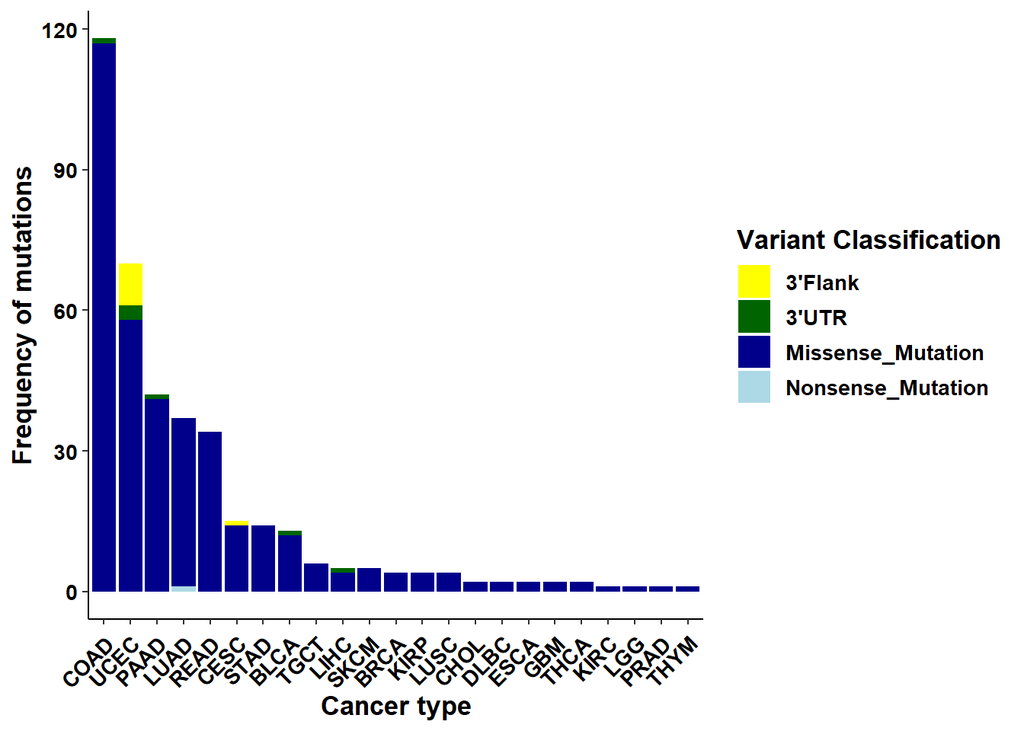

```r
data_KRAS_s <- subset(TCGA_mutation_data, Hugo_Symbol == "KRAS" & !Variant_Classification == "Silent")

data_KRAS_s <- as.data.frame(table(data_KRAS_s$type, data_KRAS_s$Variant_Classification))

ggplot(data=data_KRAS_s, aes(x=reorder(Var1,-Freq), y=Freq, fill = Var2)) +
  geom_bar(stat="identity") + theme_classic() + labs(y = "Frequency of mutations", x = "Cancer type",fill = "Variant Classification") +
  theme(axis.text.x = element_text(angle = 45, vjust = 0.9, hjust=1),
        text = element_text(face = "bold", size = 13, color = "black"),
        axis.text = element_text(color = "black"))+
  scale_fill_manual(values = c("yellow", "darkgreen", "blue4", "lightblue", "maroon3"))
```

#3. Plot shows the number of amino acid changes within KRAS

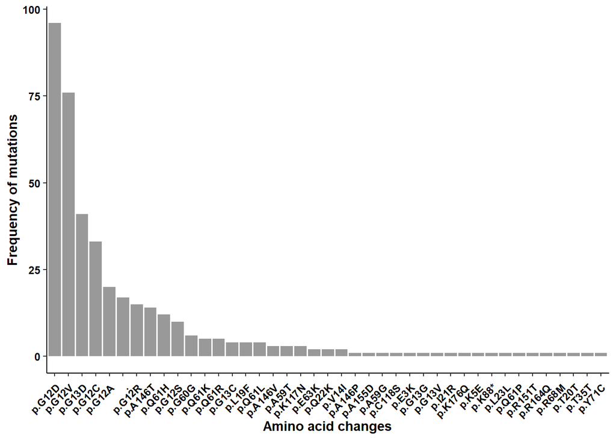

```r
data_KRAS <- subset(TCGA_mutation_data, Hugo_Symbol == "KRAS")
data_KRAS_s <- as.data.frame(table(data_KRAS$HGVSp_Short))
ggplot(data=data_KRAS_s, aes(x=reorder(Var1,-Freq), y=Freq)) +
  geom_bar(stat="identity", fill = "#999999") + theme_classic() + labs(y = "Frequency of mutations", x = "Amino acid changes") +
  theme(axis.text.x = element_text(angle = 45, vjust = 0.9, hjust=1),
        text = element_text(face = "bold", color = "black"),
        axis.text = element_text(color = "black"))
```

#4. According to the data, the most frequent G12D KRAS mutation occur in Colon adenocarcinoma (COAD). Below are details:

```r
#a. Raw numbers


TCGA_mutation_data %>%
  filter(Hugo_Symbol == "KRAS" & HGVSp_Short == "p.G12D") %>%
  count(type) %>%   slice(which.max(n))
```

```
##   type  n
## 1 COAD 27
```